# Analysis of observational data, to calculate the Delayed-Tau model parameters

Δημήτρης Παπαχριστόπουλος

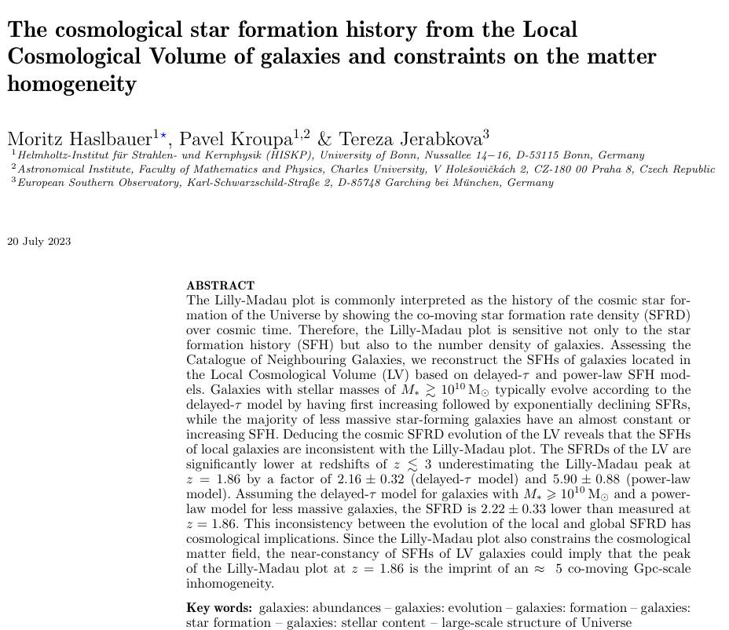

- **Αστρογένεση & Εξέλιξη**: Το delayed-τ model προσεγγίζει την ιστορία του ρυθμού αστρογένεσης.
- **Παράμετροι**: Υπολογισμός παραμέτρων του μοντέλου.
- **Ασυμφωνίες**: Το μοντέλο παρουσιάζει ασυμφωνίες με καθιερωμένες κοσμολογικές θεωρίες και παρατηρησιακά δεδομένα

# Lilly-Madau Plot

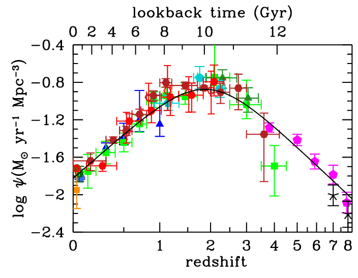

Madau and Dickinson (2014)

# Delayed-$τ$ model

$$SFR_{del}(t_{sf})=A_{del}\frac{t_{sf}}{\tau^2}e^{-\frac{t_{sf}}{\tau}}\ \left[\frac{M_\odot}{yr} \right],\$$

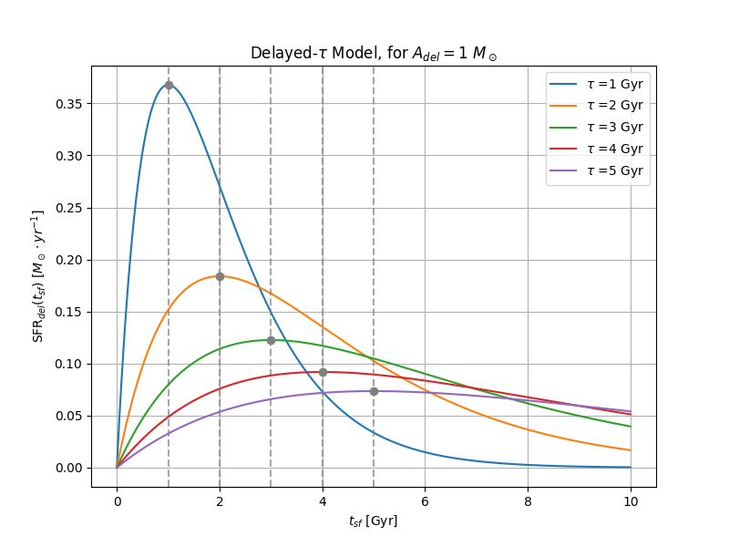

- $t_{sf} = T_{\text{universe}} - t_{\text{start}}$
- $\tau$ = timescale, ο χρόνος στον οποίο παρουσιάζει peak το SFR
- $A_{del}$ = σταθερά κανονικοποίησης [$M_\odot$]

# Δεδομενα

Γαλαξίες του Local Cosmological Volume

- $D \leq 10$ Mpc
- Redshift: $z \approx 0$

| Table | Number of galaxies |
| --- | --- |
| UNGC | 1321 |
| HECATE | 2901 |
| Join | **3934** |

- Για αυτούς τους γαλαξίες έχουμε:
  - SFR από Hα, FUV και IR
  - Αστρικές μάζες
  - **1761** γαλαξίες με μετρήσεις SFR και $M_*$

## FUV → IR

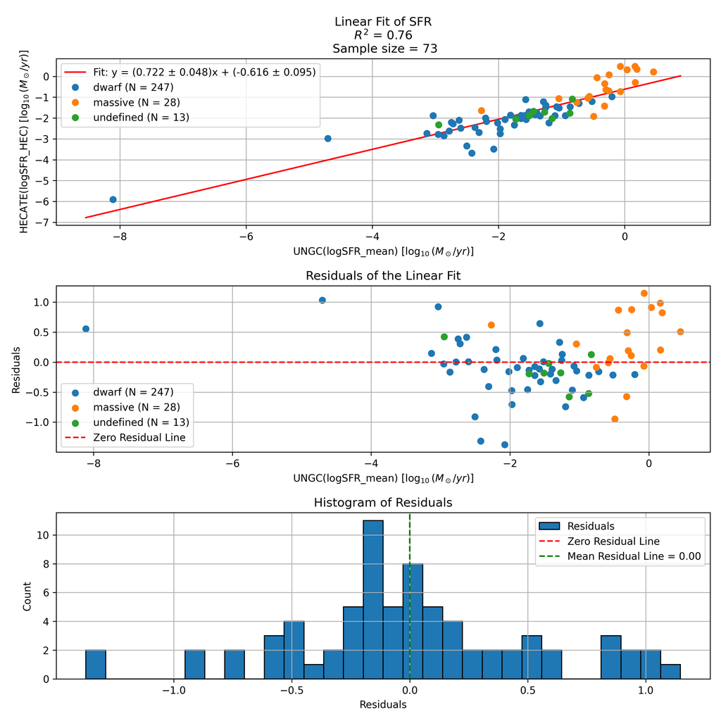

# Πρωτη προσεγγιση

- Σύστημα 2 εξισώσεων και 2 μεταβλητών ($A_{del},\ \tau$), κρατώντας το $t_{sf} = 13.6$ Gyr σταθερό.
- Λύση με υπολογιστικές μεθόδους
  - Newton-Ramphson
- Θα γίνει για *όλους* τους γαλαξίες του τελικού καταλόγου.

## Υπολογισμος $\tau$

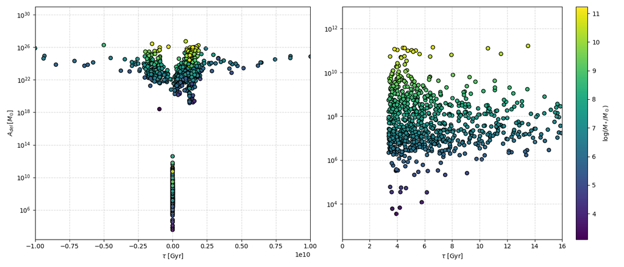

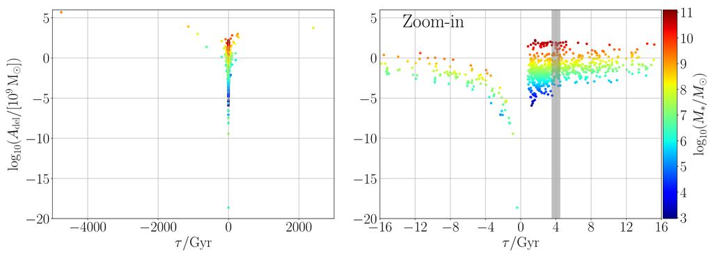

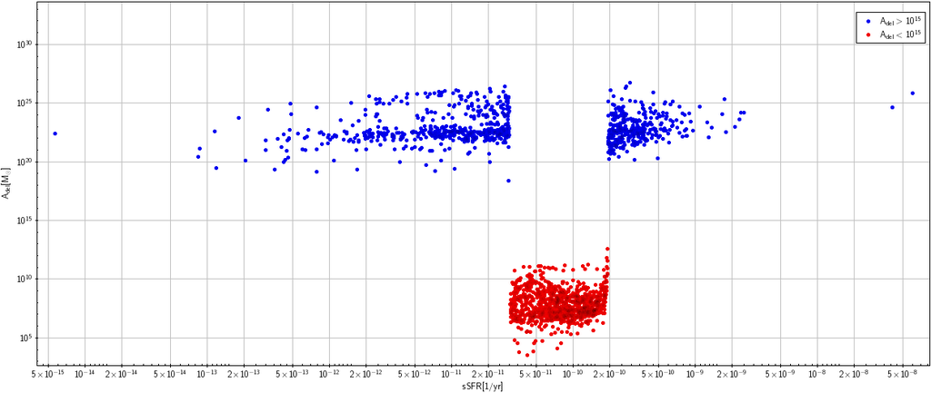

$\text{sSFR}=\frac{\text{SFR}}{M_*}$

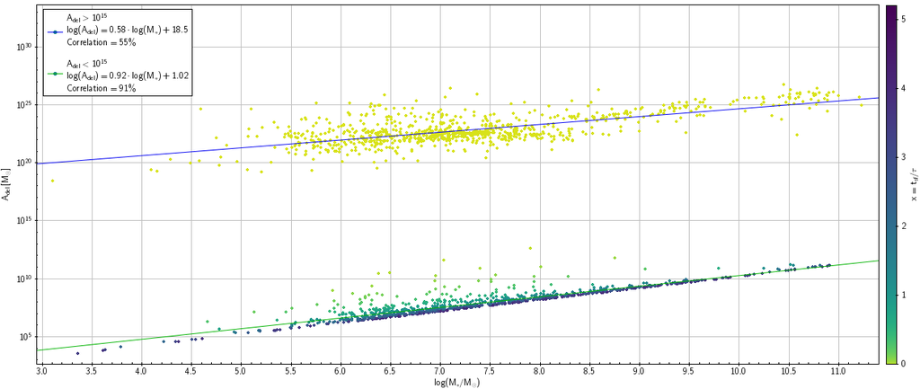

$A_{del}=M_*\frac{\zeta}{1-(x+1)e^{-x}},\ \zeta\approx1.3$

- **Προβλήματα Μεθόδου:**
  - Επιτρέπει την ύπαρξη αρνητικών $\tau$
  - $t_{sf} = 13.6\, \text{Gyr}$, αποκλείει την περίπτωση κάποιοι γαλαξίες να έχουν διαφορετικό $t_{sf}$
  - Το εκθετικό προκαλεί αστάθεια στο σύστημα.

# Markov Chain Monte Carlo

Υπολογίζει και τις 3 μεταβλητές ταυτόχρονα, βάση κάποιας κατανομής

- $t_{sf}\sim \text{uniform(1 Gyr, 13.8 Gyr)}$,
- $\tau \sim \text{uniform(1 Gyr, 20 Gyr)}$,
- $\tau \sim \text{normal}(\text{mean = 4 Gyr, } \sigma = 1)$,

# Συγκριση Μεθοδων

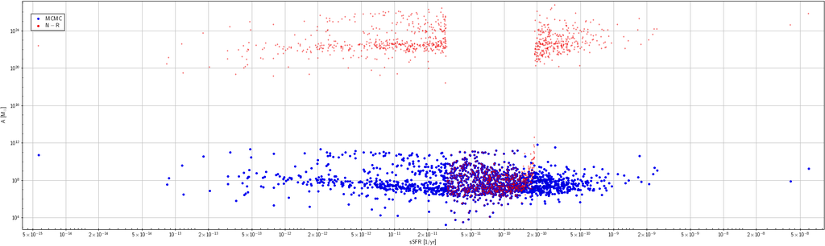

$\text{sSFR}=\frac{\text{SFR}}{M_*}$

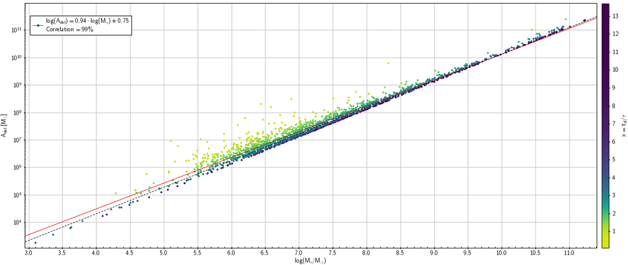

$A_{del}=M_*\frac{\zeta}{1-(x+1)e^{-x}},\ \zeta\approx1.3$

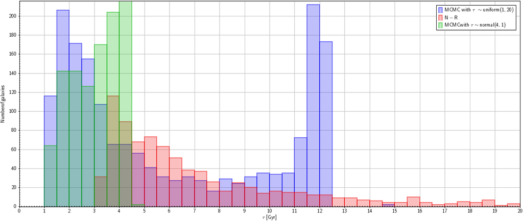

- N-R: $\tau\in [3,\infty]$,
- MCMC uniform $\tau$ prior: 2 peak, ($\sim 2 Gyr,\sim 12 Gyr$),
- MCMC normal $\tau$ prior: Τα αποτελέσματα είναι πιο κοντά στην βιβλιογραφία

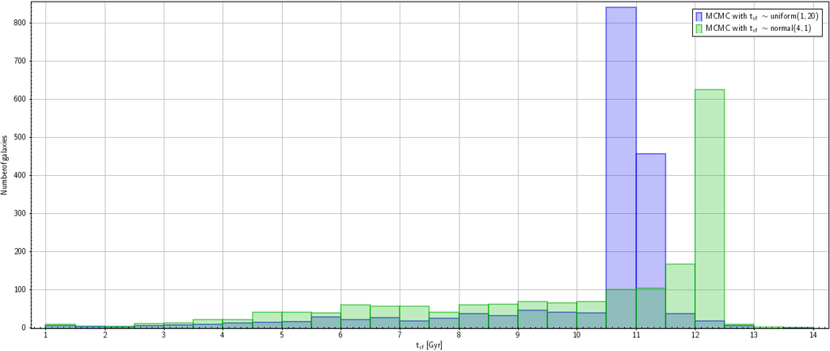

Τα αποτελέσματα από το normal prior είναι πιο κοντά με την υπόθεση $t_{sf} = 13.6$ Gyr

# SFRD reconstruction

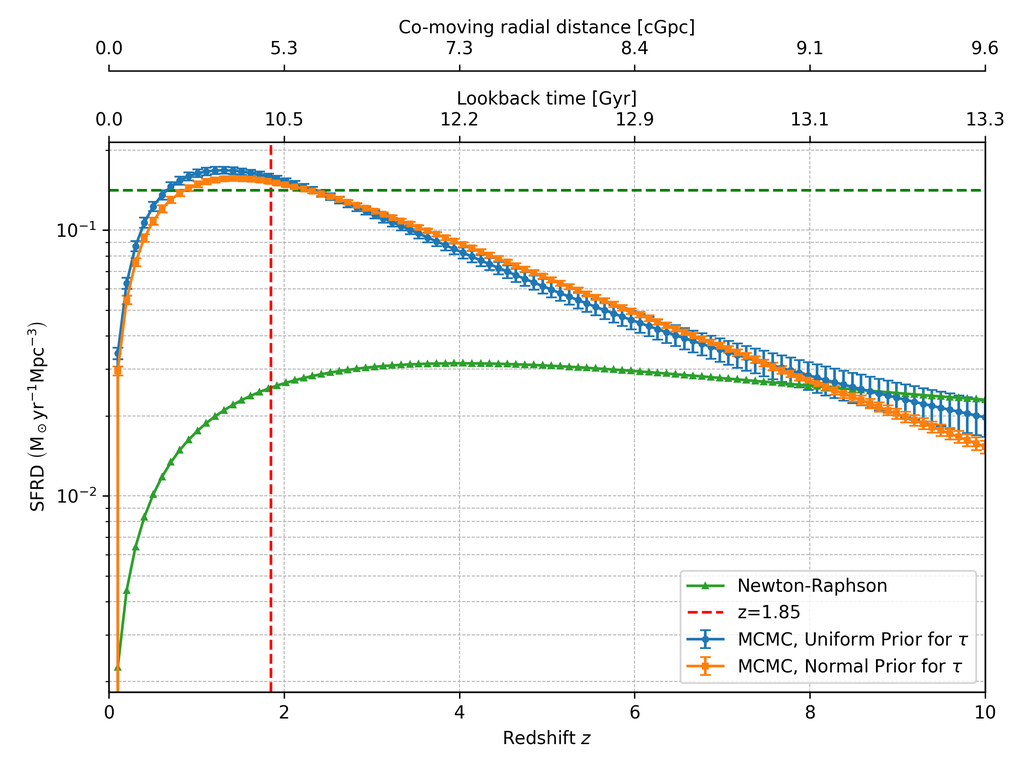

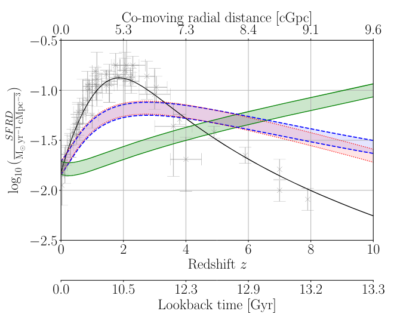

Haslbauer, Kroupa, and Jerabkova (2023)

MCMC έχει ίδια τάξη μεγέθους με το Lilly-Madau Plot

# Μελλοντικα σχεδια

- Έλεγχος διαφορετικών priors για καλύτερα προσσέγγιση του Lilly-Madau Plot
- Συνδιασμός με άλλα παραμετρικά μοντέλα
- SFH reconstruction και σύγκριση με πειραματικά δεδομένα, ανά γαλαξία.

Haslbauer, Moritz, Pavel Kroupa, and Tereza Jerabkova. 2023. “The Cosmological Star Formation History from the Local Cosmological Volume of Galaxies and Constraints on the Matter Homogeneity.” *Monthly Notices of the Royal Astronomical Society* 524 (3): 3252–62. https://doi.org/10.1093/mnras/stad1986.

Madau, Piero, and Mark Dickinson. 2014. “Cosmic Star Formation History.” *Annual Review of Astronomy and Astrophysics* 52 (1): 415–86. https://doi.org/10.1146/annurev-astro-081811-125615.